# Protocol variables

Descriptive analysis

Compounds included in document:

```
## [1] "MEPA_total" "ETPA_total" "BPA_total"  "OXBE_total" "TRCS_total"
```

# 1 Intro

In this document we analyse the link between a select set of Sepages protocol variables (with a special focus on batch) and the urinary levels of all phenols with > 80% samples > LOD.

The protocol variables under study are:

- Batch
- Defreeze time
- Transport time

As a reminder, the life cycle of a urine sample in sepages is:

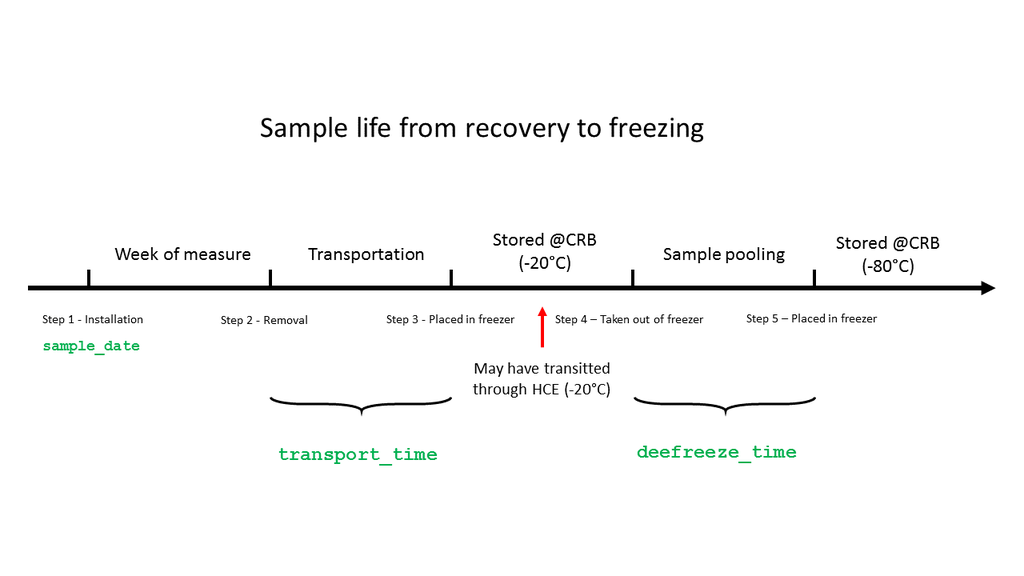

Sample process in sepages

Number of urine samples by trimester

| period | n |
| --- | --- |
| T1 | 477 |
| T3 | 456 |

# 2 Batch

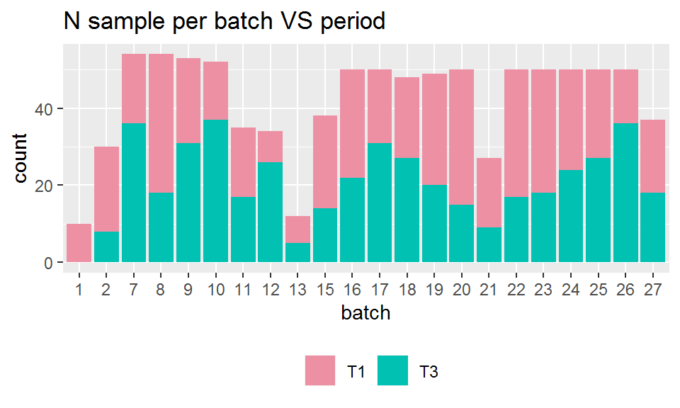

- Batch 7 used as reference

# 3 Defreeze time and transport time

Impossible values such as negative or null times were set to `NA`:

- N negative or null defreeze times: 10
- N negative or null transport times: 9

Transport time was log transformed due to strong skewness.

And defreeze times were used as tertiles because of the outliers that were pulling the trends.

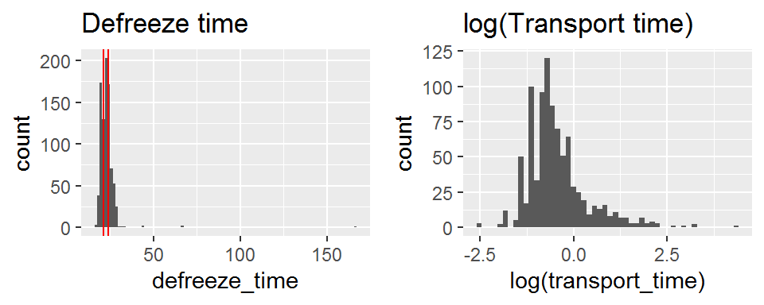

# 4 Censorship

Data below LOD will be imputed by *LOD/sqrt(2)*, OK when few number of samples < LOD.

| compound | n_below_lod |
| --- | --- |
| BPA | 12 |
| ETPA | 4 |
| MEPA | 0 |
| OXBE | 2 |
| TRCS | 16 |

# 5 Raw level distributions

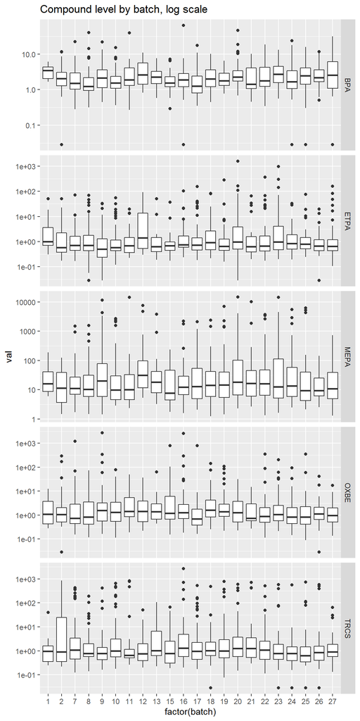

# 6 Associations with protocol vars

## 6.1 DAG

DAG for variables in link with protocol variables.

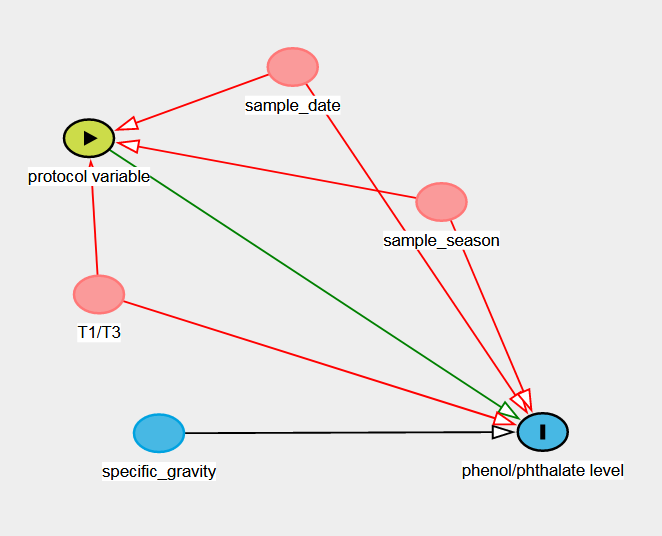

## 6.2 Method

A multiple linear regression is fit between compound level and the three protocol variables of interest and further adjusted on known confounding factors (cf. DAG + phenols paper):

- `specific_gravity`
- `sample_date` (linear time trend)
- `sample_season` (categorical)
- `period` (T1 vs T3)
- `mom_edu` (categorical)
- `mom_age` (continuous)
- `mom_bmi` (continuous)
- `parity` (continuous)

**Note: need to add occupation for bisphenols + tobacco**

Corrections are then applied to all protocol variables with p < 0.2 using the betas from this model following the procedure described in (Mortamais et al. 2012). A second correction will also take into account specific gravity.

## 6.3 Model outputs

Here are the p-values for the variables of interest from the multivariate model used to decide which protocol variables to use for correction.

p-values in the adjusted regressions

| compound | p_batch | p_def_time | p_trans_time |
| --- | --- | --- | --- |
| BPA | 0.002 | 0.384 | 0.883 |
| ETPA | 0.007 | 0.626 | 0.303 |
| MEPA | 0.263 | 0.112 | 0.012 |
| OXBE | 0.023 | 0.165 | 0.588 |
| TRCS | 0.708 | 0.817 | 0.699 |